# Short-term impacts of island restoration on seabirds in Gwaii Haanas (Feb. 15 update)

# BACI

Task 2e) Test whether restoration resulted in an increase in seabird vocalization metrics, by species (abundance), using BACI design.

##### Experimental Design

In phase 2, eradication of rats took place post-breeding season, 2013. There were two impact sites (Faraday, Murchison) and 4 control sites (Alder, Hotspring/House, Ramsay) and in general, 3 years of sampling before impact (2011, 2012, 2013) and 2 years of sampling after impact (2014, 2015). In total, there were 53 replciate:year combinations (after filtering out replicates that sampled outside of our time-window; see below). Replicates were located at fixed locataions across years. The sampling design was unbalanced; the number of replicates at each site ranged from 1 to 8, and replicates did not consistently sample in all years (2011-2015).

##### Statistical model

Prior to analysis, each response was logit-transformed (empirical logit transformation) to account for proportions being bounded at 0 and 1. For each species:phase:response combination, we fit a linear mixed-effects model within R, using the lmer() function within the lme4 package. Due to the unbalanced experimental design (e.g. not all monitoring locations consistently monitored in every year), the response was calculated at each monitoring location rather than each island group; this allowed for testing random effects of replicate:year. For all models, fixed effects included period (Before/After), siteclass (Control/Impact), and period:siteclass interaction; random effects included year, island and site (nested within island).

We used ANOVA (type 3 with Kenward-Roger approximation for degrees of freedom) to determine statistical significance of fixed effects. A p-value < 0.05 for the interacation term indicated presence of a BACI effect. We determined the magnitude of the BACI effect by calculating marginal means within the lsme package and dtermined BACI contrast (i.e. direction and magnitude of BACI effect), along with 95% Confidence Intervals (CI).

Key assumptions of the model:

- System is in equilibirum before and after impact.
  - This assumption may not be valid as recovery of seabird breeding population may occur over a longer time period than is accounted for in this study.
- Variance is homogeneous, data are normally distributed.
  - We used several diagnostic plots (residuals vs. fitted values, qqplot for normality) to test validity of the statistical model and associated p-values.
- Observations are independent within each site-year combination and across years.
  - Sites were spaced sufficeintly far apart in space to warrant assumption of independence.

## Ancient Murrelet

Figure 1: Phase 1 temporal coverage by site. Colour indicates site class (‘Control’, ‘Impact’). Vertical black lines indiacte sampling window used for analysis.

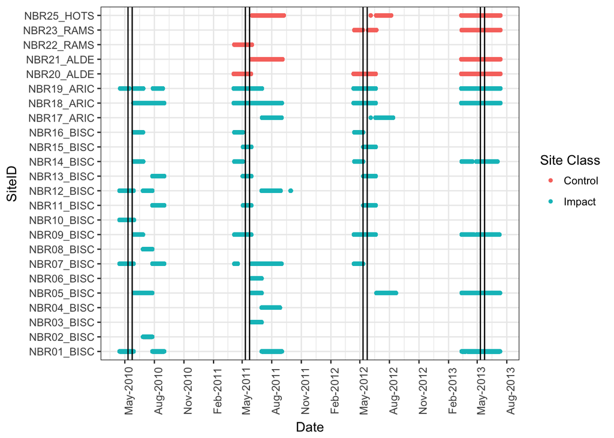

Figure 2: Phase 2 temporal coverage by site. Colour indicates site class (‘Control’, ‘Impact’). Vertical black lines indiacte sampling window used for analysis.

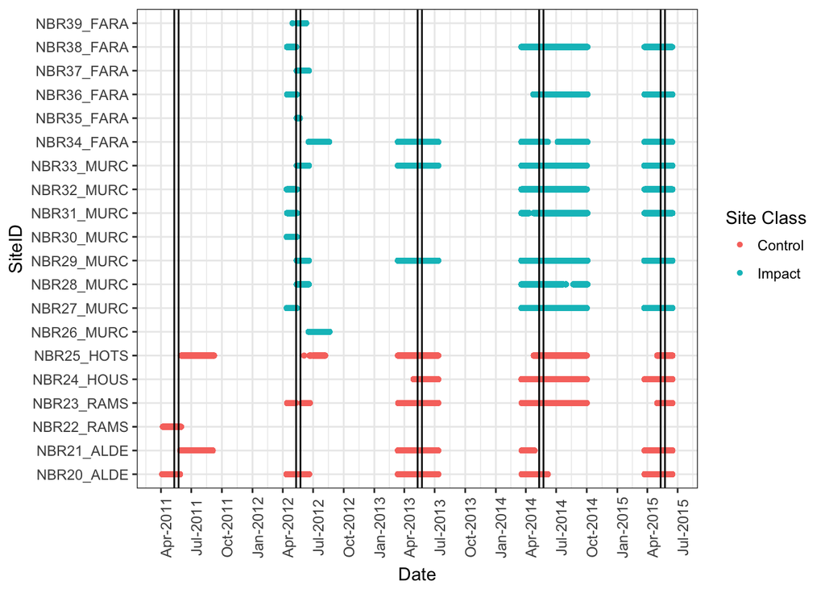

### Mean proportions by island.

Figure 3: Phase 1 mean proportion of recordings with detection of at least one individual at islands. Color indicates whether island was control or impact; shape indicates island group

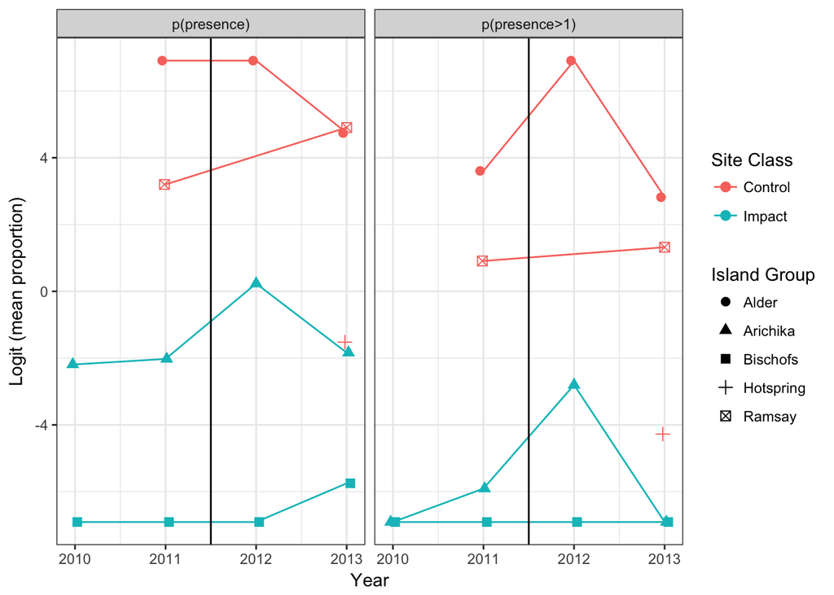

Figure 4: Phase 2 mean proportion of recordings with detection of at least one individual at islands. Color indicates whether island was control or impact; shape indicates island group

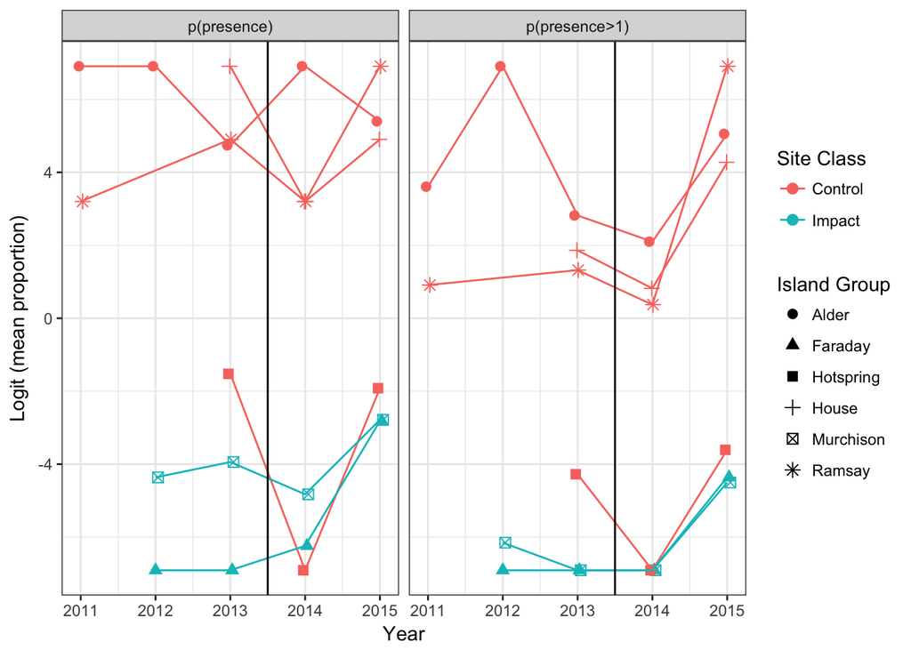

### Statistical model results

#### Phase 1, p(presence)

Table 1: Summary model coefficients; Ancient Murrelet, Phase 1, proportion of recordings with detected presence.

[output not shown]

[output not shown]

[output not shown]

| Term | Estimate | SE | df | p-value |
| --- | --- | --- | --- | --- |
| Intercept | -2.844 | 1.492 | 3.1 | 0.149 |
| Period | 0.561 | 0.785 | 2.7 | 0.531 |
| Site Class | -4.672 | 2.009 | 2.6 | 0.116 |
| Period:SiteClass | -0.436 | 0.623 | 18.7 | 0.492 |

Table 5: BACI marginal means; Ancient Murrelet, Phase 1, proportion of recordings with more than one individual detected.

| Site Class | Period | Marginal Mean | SE | df | Lower CL | Upper CL |
| --- | --- | --- | --- | --- | --- | --- |
| Control | Before | -0.155 | 2.134 | 5.0 | -5.652 | 5.343 |
| Impact | Before | -6.326 | 2.257 | 2.9 | -13.711 | 1.060 |
| Control | After | 1.075 | 1.967 | 3.7 | -4.594 | 6.743 |
| Impact | After | -5.969 | 2.253 | 2.8 | -13.372 | 1.434 |

Table 6: BACI effect and 95% confidence intervals; Ancient Murrelet, Phase 1, proportion of recordings with more than one individual detected.

| Estimate | SE | df | Lower CL | Upper CL | p-value |
| --- | --- | --- | --- | --- | --- |
| 0.873 | 1.246 | 18.7 | -1.738 | 3.483 | 0.492 |

##### Phase 2, p(presence)

Table 7: Summary model coefficients; Ancient Murrelet, Phase 2, proportion of recordings with detected presence.

| Term | Estimate | SE | df | p-value |
| --- | --- | --- | --- | --- |
| Intercept | -1.168 | 1.468 | 3.7 | 0.475 |
| Period | 0.120 | 0.819 | 3.1 | 0.892 |
| Site Class | -5.792 | 1.946 | 2.9 | 0.061 |
| Period:SiteClass | 1.243 | 0.485 | 30.3 | 0.016 |

Table 8: BACI marginal means; Ancient Murrelet, Phase 2, proportion of recordings with detected presence.

| Site Class | Period | Marginal Mean | SE | df | Lower CL | Upper CL |
| --- | --- | --- | --- | --- | --- | --- |
| Control | Before | 3.464 | 1.847 | 5.1 | -1.246 | 8.174 |
| Impact | Before | -5.970 | 2.320 | 3.2 | -13.045 | 1.106 |
| Control | After | 2.392 | 1.883 | 5.3 | -2.356 | 7.140 |
| Impact | After | -4.556 | 2.333 | 3.3 | -11.619 | 2.506 |

Table 9: BACI effect and 95% confidence intervals; Ancient Murrelet, Phase 2, proportion of recordings with detected presence.

| Estimate | SE | df | Lower CL | Upper CL | p-value |
| --- | --- | --- | --- | --- | --- |
| -2.486 | 0.97 | 30.3 | -4.466 | -0.505 | 0.016 |

##### Phase 2, p(presence>1)

Table 10: Summary model coefficients; Ancient Murrelet, Phase 2, proportion of recordings with more than one individual detected.

| Term | Estimate | SE | df | p-value |
| --- | --- | --- | --- | --- |
| Intercept | -2.833 | 1.531 | 4.9 | 0.124 |
| Period | 0.609 | 1.048 | 2.9 | 0.604 |
| Site Class | -5.345 | 1.931 | 3.4 | 0.060 |
| Period:SiteClass | 0.784 | 0.484 | 32.0 | 0.115 |

Table 11: BACI marginal means; Ancient Murrelet, Phase 2, proportion of recordings with more than one individual detected.

| Site Class | Period | Marginal Mean | SE | df | Lower CL | Upper CL |
| --- | --- | --- | --- | --- | --- | --- |
| Control | Before | 0.908 | 1.892 | 6.2 | -3.686 | 5.502 |
| Impact | Before | -7.434 | 2.409 | 4.5 | -13.849 | -1.019 |
| Control | After | 0.985 | 1.969 | 6.3 | -3.777 | 5.747 |
| Impact | After | -5.790 | 2.449 | 4.6 | -12.249 | 0.670 |

Table 12: BACI effect and 95% confidence intervals; Ancient Murrelet, Phase 2, proportion of recordings with more than one individual detected.

| Estimate | SE | df | Lower CL | Upper CL | p-value |
| --- | --- | --- | --- | --- | --- |
| -1.567 | 0.968 | 32 | -3.539 | 0.404 | 0.115 |